# Trenton Public School District — NJ School Data Almanac – NJ District Profiles

NJ School Data Almanac

Trenton Public School District

MERCER COUNTY · TRADITIONAL PUBLIC DISTRICT · DFG A · 14,380 STUDENTS (2026)

14,380

Students

60%

4-yr grad rate

7.5%

Gr 3-8 ELA

34%

Chronically absent

$19,149

Per pupil

*10 things the data says about Trenton Public School District. Every figure is computed from New Jersey Department of Education data via the njschooldata package — nothing is estimated. Comparisons use District Factor Group (DFG) peers (39 districts in DFG A).*

No. 1 ACHIEVEMENT

## Trenton’s Elementary ELA Proficiency Kept Falling After COVID, Hitting 7.5% in 2024

On the NJSLA, grades 3-8 reading proficiency dropped from 19.4% in 2019 to 7.5% in 2024, with no rebound in the recovery years.

These are the students who will reach Trenton High in the next few years, where the four-year graduation rate already sits at 60.0%. The data raises a question it cannot answer: if proficiency is still falling four years after schools reopened, what is driving a decline that recovery time alone has not reversed?

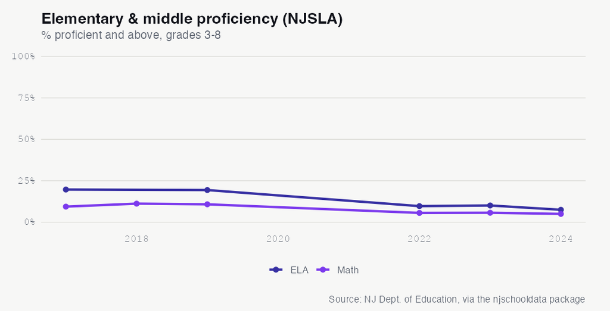

See the underlying data ›

No. 2 EQUITY

## Trenton’s Former English Learners Outscore Everyone in Reading, 28% vs 7.5% Districtwide

On the 2024 NJSLA, students who exited English-learner status posted the district’s highest reading proficiency, while current English learners scored 1.1%.

Trenton’s 2024 grade 3-8 reading results contain a counterintuitive twist. The single highest-scoring group was not white students or affluent students; it was former English learners, who reached 28.1% proficiency, nearly four times the districtwide rate of 7.5%. Students recently reclassified out of multilingual-learner status scored 25.7%, also far ahead of the field.

The contrast with current English learners is dramatic. Students still classified as limited English proficient scored 1.1% proficient in reading, and students receiving special-education accommodations scored 2.3%. Among the larger demographic groups the numbers cluster tightly near the district floor: Hispanic students at 7.4%, white at 7.1%, Black at 7.0%, all within a half-point of one another.

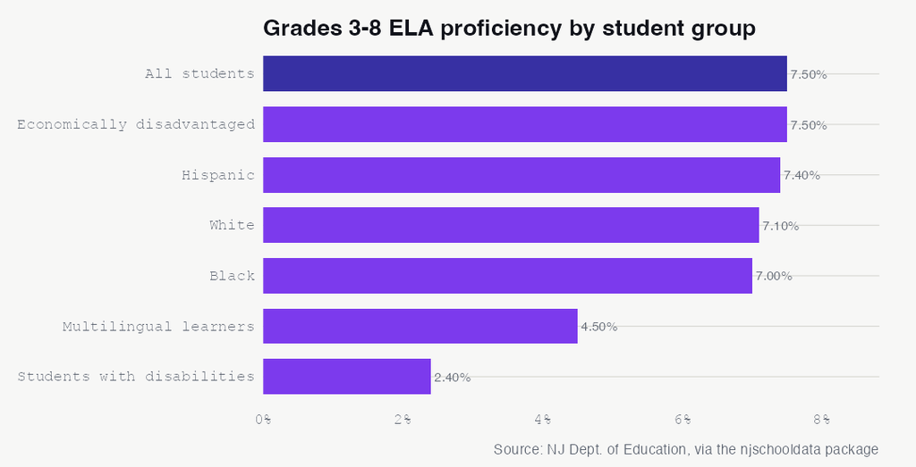

See the underlying data ›

No. 3 EQUITY

## Trenton’s Black Students Graduate at 69.9%, Versus 56.1% for the District’s Largest Group

In Trenton’s 2025 cohort, the highest-graduating large group is Black students, and the students who are economically disadvantaged outpace the district as a whole.

Even more striking, students who are economically disadvantaged graduated at 70.7%, the highest rate of any major subgroup and more than ten points above the total. In most New Jersey districts, economic disadvantage tracks with lower graduation; in Trenton, where 59.4% of students qualified for free or reduced lunch in 2026, that subgroup outperformed the district average.

The smaller groups tell their own story. White students, a cohort of just 19, graduated at 52.6%, and students who are multilingual learners finished at 51.0% across a sizable 531-student cohort. The data raises a question it cannot answer on its own: what is working for Trenton’s Black and economically disadvantaged students that has not yet reached its Hispanic and multilingual-learner majorities?

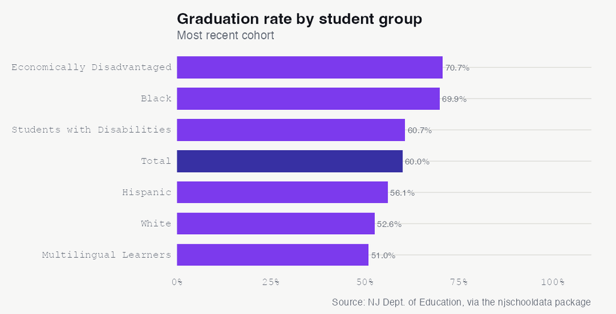

See the underlying data ›

No. 4 DEMOGRAPHICS

## Trenton’s Black Enrollment Share Was Cut Nearly in Half Since 2015, Falling From 54% to 30%

Over eleven years the district flipped from majority-Black to roughly two-thirds Hispanic, the largest demographic change in its data.

A decade ago Trenton was a majority-Black district. In 2015, Black students made up 54.3% of enrollment and Hispanic students 43.1%. By 2026 those positions had reversed: Hispanic students were 67.2% of the district and Black students 29.6%. The Black share fell 24.7 percentage points, the largest single demographic shift in Trenton’s data, while the Hispanic share rose 24.1 points.

The change was steady rather than sudden, with the Black share declining nearly every year and crossing below the Hispanic share between 2017 and 2018. By 2020 the district was already 62.0% Hispanic. White enrollment, never more than 1.5%, settled at 0.9%, while the multiracial share quietly grew from 0.4% to 1.8%.

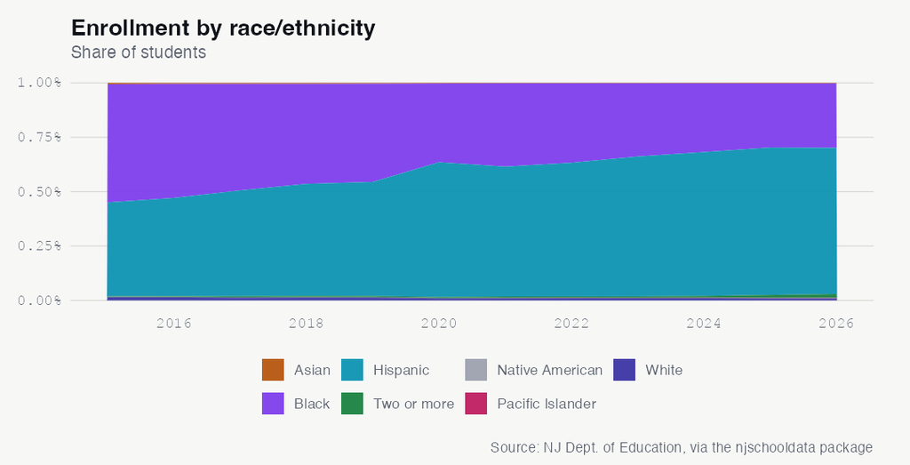

See the underlying data ›

No. 5 GRADUATION

## Trenton’s Four-Year Graduation Rate Sits at 60%, in the 4th Percentile of Its Peer Group

Even among 39 high-need DFG A districts, where the median graduation rate is 85%, Trenton trails by 25 percentage points.

Trenton’s 60.0% four-year graduation rate in 2025 is low not just statewide but against the districts most like it. Among the 39 districts in its District Factor Group, the lowest-income tier in New Jersey, the median graduation rate is 85.0%. Trenton’s 60.0% places it in the 4th percentile of that peer group, a gap of 25 percentage points from the typical high-need district.

The rate has been stuck in a narrow band for years. It was 64.0% in 2020, dipped to 60.3% in 2022, recovered to 65.9% in 2024, then fell back to 60.0% in 2025. Across the same span the graduating cohort grew substantially, from 979 students in 2020 to 1,355 in 2025, so a flat-to-declining rate means a growing number of students leaving without a diploma in four years.

The comparison matters because DFG A peers face the same headwinds of poverty and language barriers that Trenton does, yet most graduate far more of their students. The question for Trenton’s board is what those peers have unlocked that the district has not.

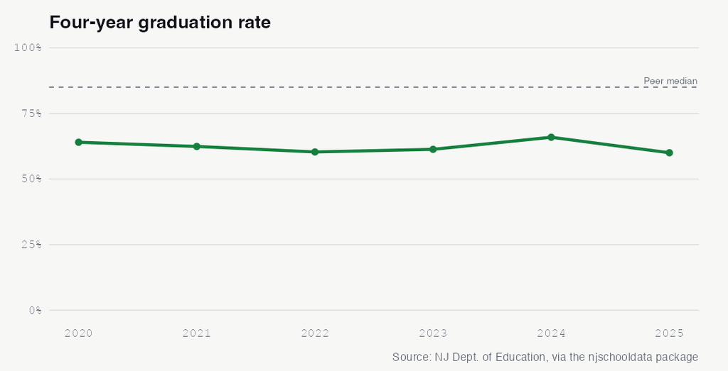

See the underlying data ›

No. 6 DEMOGRAPHICS

## Trenton’s English Learners Nearly Tripled to 40% of Students Since 2015

The count of students classified as limited English proficient rose from 1,715 to 5,795 as the district’s Hispanic majority grew.

As Trenton’s student body shifted toward a Hispanic majority, its population of English learners surged. In 2015, 15.3% of students, 1,715 children, were classified as limited English proficient. By 2026 that share had reached 40.3%, covering 5,795 students, after peaking at 41.6% in 2025.

The growth accelerated sharply after 2019. The share jumped from 21.3% that year to 30.0% in 2020, then climbed past 35% in 2024 before cresting above 41%. In just over a decade the number of students needing English-language services more than tripled.

This growth sits directly alongside Trenton’s reading data, where current English learners scored 1.1% proficient on the 2024 NJSLA while students who exited the program reached 28.1%. With two of every five students now learning English, the question is whether the district’s language-instruction capacity, from bilingual teachers to translated family communication, has scaled with a population that has grown this fast.

See the underlying data ›

No. 7 ATTENDANCE

## 1 in 3 Trenton Students Was Chronically Absent in 2024, 10 Points Above the Peer Median

Chronic absenteeism reached 34.0% in 2024, higher than the 24.1% median for the district’s peer group and above its own pre-pandemic level.

In 2024, 34.0% of Trenton students were chronically absent, meaning roughly one in three missed 10% or more of the school year. That rate sits a full ten points above the 24.1% median for districts in Trenton’s peer group, and above the district’s own pre-pandemic mark of 30.0% in 2019.

The pandemic years were severe. Chronic absence spiked to 69.6% in 2021, when nearly seven in ten students crossed the threshold during remote and hybrid instruction. It fell back to 37.5% in 2022 and rose again to 42.2% in 2023 before easing to 34.0% in 2024. The recovery is real but incomplete, leaving the rate higher than where it started.

Chronic absence is tightly linked to academic outcomes, and Trenton’s elevated rate is one plausible thread running through its falling proficiency and low graduation numbers. Whether attendance continues its slow climb back toward the 30% baseline, or settles at this higher plateau, is a trend the district will be watching closely.

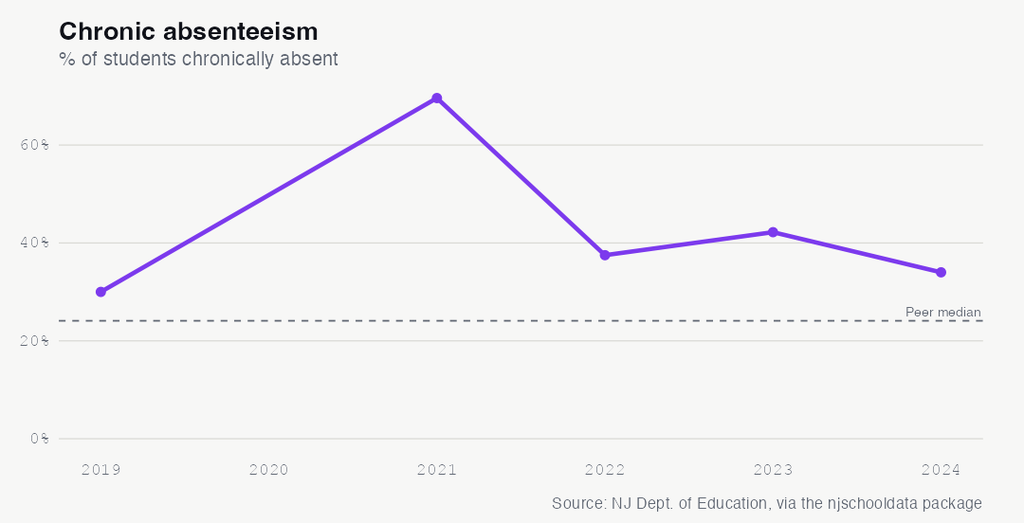

See the underlying data ›

No. 8 ACHIEVEMENT

## Trenton’s High-School Math Proficiency Was 11.6% in 2025 as Its Reading Score Slid Back

On the 2025 NJGPA, 11.6% of Trenton students met the math bar while ELA proficiency fell from 38.1% to 31.9% in a single year.

Trenton’s high-school proficiency picture mirrors the slide seen lower down in its grades. On the 2025 New Jersey Graduation Proficiency Assessment, 11.6% of the 860 students tested scored proficient or above in math. In English language arts, 31.9% of 831 students cleared the bar, down sharply from 38.1% the year before.

The ELA figure had been the brighter spot in Trenton’s testing data, holding above 36% in both 2023 and 2024 before the 2025 drop of more than six points. Math is newly reported in 2025, offering no trend line to judge against, only the stark snapshot that fewer than one in eight tested students met the standard.

These high-school results sit at the end of a pipeline that feeds from grade 3-8 classrooms where reading proficiency has fallen to 7.5%. The question the numbers raise is whether the 2025 ELA dip is a one-year fluctuation or the leading edge of the same decline now visible in the elementary grades.

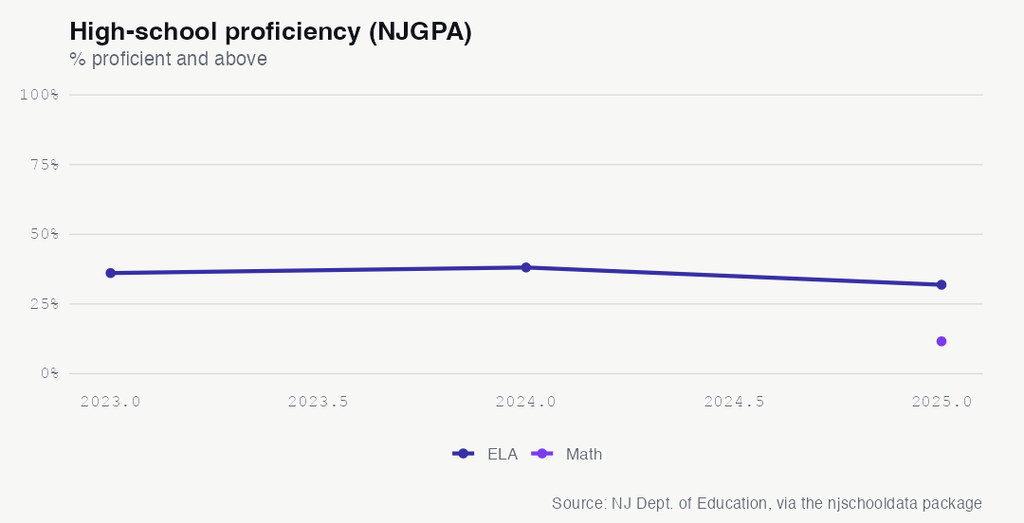

See the underlying data ›

No. 9 ENROLLMENT

## Trenton’s Enrollment Grew 29% Since 2015, Then Fell 7% in a Single Year

The district added 3,197 students between 2015 and 2026 even as many urban districts shrank, but 2026 brought the steepest drop in its data.

While enrollment fell across much of urban New Jersey, Trenton grew. The district’s student count rose from 11,183 in 2015 to 14,380 in 2026, a gain of 3,197 students, or 28.6%. The growth was driven in part by a sharp run-up around the pandemic: enrollment jumped 7.2% in 2019 and 11.6% in 2021, climbing from a trough of 10,962 in 2017 to a peak of 15,474 in 2025.

The most recent year breaks the trend. Enrollment fell 1,094 students in 2026, a 7.1% decline, the steepest single-year drop in the data and a reversal of more than a decade of growth. Whether this is a one-year correction or the start of a new direction is not yet clear from a single data point.

The surge coincided with Trenton’s demographic flip toward a Hispanic majority and its tripling of English learners, suggesting much of the growth came from a changing immigrant-origin population. For a district that built capacity around a growing student body, the open question is whether the 2026 decline signals that growth has run its course.

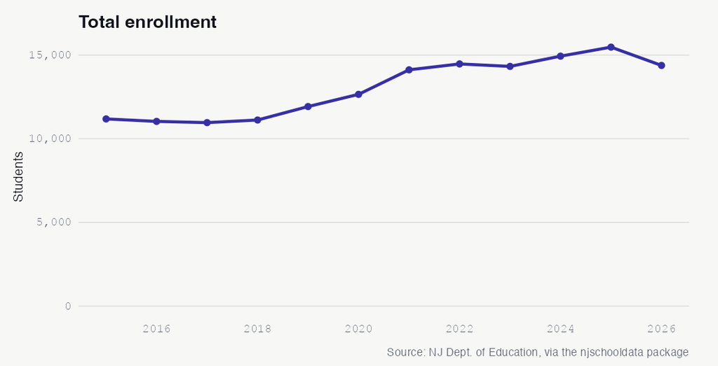

See the underlying data ›

No. 10 FINANCE

## Trenton Spends $19,149 Per Student, Right at Its Peer Group’s Median

After swinging from the cheapest district in its group to mid-pack, Trenton’s per-pupil spending sits in the 50th percentile of DFG A peers.

Trenton’s 2024 per-pupil spending of $19,149 lands almost exactly at the middle of its peer group, the 50th percentile among 39 DFG A districts, just below the peer median of $19,338. Since 2014 the figure has risen 8.1%, a modest increase compared with the demographic change the district absorbed over the same period.

The path there was turbulent. Per-pupil spending fell from $17,720 in 2014 to $13,914 in 2021, briefly ranking Trenton the 4th cheapest district statewide on this measure, before climbing back to $17,865 in 2022 and continuing up to $19,149 in 2024. That volatility coincided with the same years enrollment was surging, which spreads fixed costs across more students.

Where the money goes leans toward classrooms, with 51.6% of spending on classroom instruction in 2025 and a notably high 21.7% on plant operations, the cost of running and maintaining buildings. Administration took 9.1%. As the district serves a student body with growing language and attendance needs, the question is whether mid-pack spending is enough to close the gaps the rest of its data reveals.

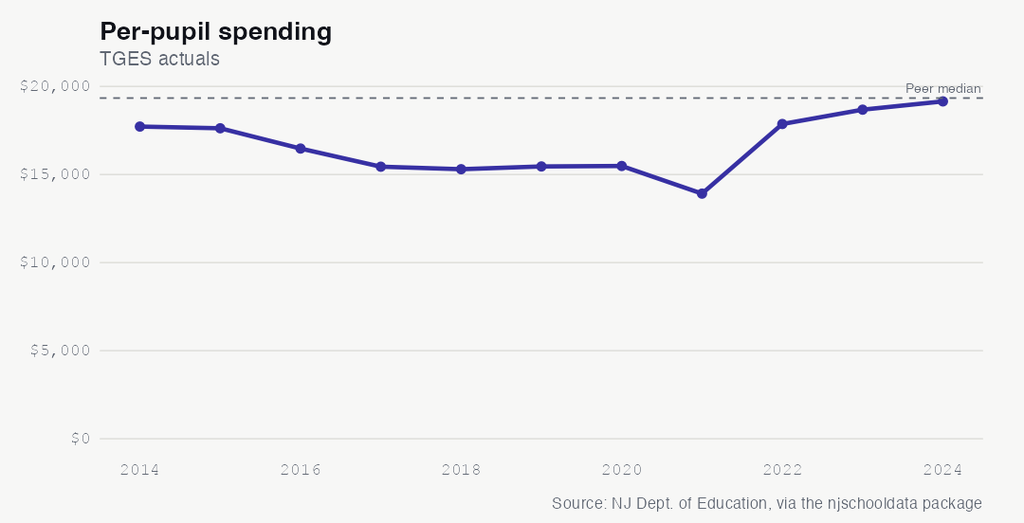

See the underlying data ›

## The Almanac

The full longitudinal record behind the stories above. Every number a reader can check.

### Enrollment (total)

| year | students | yoy | yoy_pct |
| --- | --- | --- | --- |
| 2015 | 11183 | NA | NA |
| 2016 | 11035 | -148 | -1.3 |
| 2017 | 10962 | -73 | -0.7 |
| 2018 | 11118 | 156 | 1.4 |
| 2019 | 11922 | 804 | 7.2 |
| 2020 | 12652 | 730 | 6.1 |
| 2021 | 14118 | 1466 | 11.6 |
| 2022 | 14470 | 352 | 2.5 |
| 2023 | 14323 | -147 | -1 |
| 2024 | 14935 | 612 | 4.3 |
| 2025 | 15474 | 539 | 3.6 |
| 2026 | 14380 | -1094 | -7.1 |

### Demographic share (%) by year

| end_year | white | black | hispanic | asian | native_american | pacific_islander | multiracial |
| --- | --- | --- | --- | --- | --- | --- | --- |
| 2015 | 1.5 | 54.3 | 43.1 | 0.6 | 0.1 | 0 | 0.4 |
| 2016 | 1.4 | 52.4 | 45.2 | 0.5 | 0 | 0 | 0.4 |
| 2017 | 1.2 | 49 | 48.7 | 0.5 | 0.1 | 0.1 | 0.5 |
| 2018 | 1.3 | 46 | 51.5 | 0.4 | 0.1 | 0.1 | 0.6 |
| 2019 | 1.3 | 45.2 | 52.5 | 0.4 | 0.1 | 0.1 | 0.6 |
| 2020 | 0.9 | 36.2 | 62 | 0.2 | 0.1 | 0.1 | 0.5 |
| 2021 | 1 | 38.3 | 59.8 | 0.2 | 0.1 | 0.1 | 0.7 |
| 2022 | 1 | 36.5 | 61.5 | 0.2 | 0 | 0.1 | 0.6 |
| 2023 | 1 | 33.6 | 64.4 | 0.2 | 0 | 0.1 | 0.7 |
| 2024 | 1 | 31.6 | 66.1 | 0.2 | 0 | 0.1 | 0.9 |
| 2025 | 0.9 | 29.5 | 67.8 | 0.2 | 0.1 | 0.2 | 1.4 |
| 2026 | 0.9 | 29.6 | 67.2 | 0.2 | 0.1 | 0.2 | 1.8 |

### Special populations (LEP, FRL)

| end_year | subgroup | students | pct |
| --- | --- | --- | --- |
| 2015 | lep | 1715 | 15.3 |
| 2015 | free_reduced_lunch | 9983 | 89.3 |
| 2016 | lep | 1804 | 16.4 |
| 2016 | free_reduced_lunch | 9903 | 89.7 |
| 2017 | lep | 2054 | 18.7 |
| 2017 | free_reduced_lunch | 9770 | 89.1 |
| 2018 | lep | 2354 | 21.2 |
| 2018 | free_reduced_lunch | 9815 | 88.3 |
| 2019 | lep | 2539 | 21.3 |
| 2019 | free_reduced_lunch | 9640 | 80.9 |
| 2020 | lep | 3796 | 30.0 |
| 2020 | free_reduced_lunch | 9439 | 74.6 |
| 2021 | lep | 3826 | 27.1 |
| 2021 | free_reduced_lunch | 6636 | 47.0 |
| 2022 | lep | 3907 | 27.0 |
| 2022 | free_reduced_lunch | 5759 | 39.8 |
| 2023 | lep | 4369 | 30.5 |
| 2023 | free_reduced_lunch | 7691 | 53.7 |
| 2024 | lep | 5302 | 35.5 |
| 2024 | free_reduced_lunch | 6407 | 42.9 |
| 2025 | lep | 6437 | 41.6 |
| 2025 | free_reduced_lunch | 10661 | 68.9 |
| 2026 | lep | 5795 | 40.3 |
| 2026 | free_reduced_lunch | 8541 | 59.4 |

### Graduation rate 4yr (total)

| year | grad_rate | cohort |
| --- | --- | --- |
| 2020 | 64 | 979 |
| 2021 | 62.4 | 946 |
| 2022 | 60.3 | 1025 |
| 2023 | 61.3 | 1196 |
| 2024 | 65.9 | 1148 |
| 2025 | 60 | 1355 |

### Graduation by subgroup (2025)

| subgroup | grad_rate | cohort |
| --- | --- | --- |
| economically disadvantaged | 70.7 | 931 |
| black | 69.9 | 379 |
| female | 66.7 | 570 |
| students with disabilities | 60.7 | 206 |
| total | 60.0 | 1355 |
| students experiencing homelessness | 57.1 | 42 |
| hispanic | 56.1 | 943 |
| male | 55.2 | 785 |
| white | 52.6 | 19 |
| multilingual learners | 51.0 | 531 |
| students in foster care | 23.1 | 13 |
| american indian | NA | NA |
| asian | NA | NA |
| migrant students | NA | NA |
| military-connected students | NA | NA |
| non-binary/undesignated gender | NA | NA |
| multiracial | NA | NA |

### NJGPA high-school proficiency (% proficient+)

| year | test | prof_above | valid |
| --- | --- | --- | --- |
| 2023 | ela | 36.1 | 800 |
| 2023 | math | NA | NA |
| 2024 | ela | 38.1 | 840 |
| 2024 | math | NA | NA |
| 2025 | ela | 31.9 | 831 |
| 2025 | math | 11.6 | 860 |

### NJGPA ELA by subgroup (2025)

[output not shown]

### NJSLA grades 3-8 proficiency (% proficient+, enrollment-weighted across grades)

| testing_year | test_name | prof |
| --- | --- | --- |
| 2017 | ela | 19.7 |
| 2017 | math | 9.4 |
| 2018 | math | 11.2 |
| 2019 | ela | 19.4 |
| 2019 | math | 10.8 |
| 2022 | ela | 9.7 |
| 2022 | math | 5.6 |
| 2023 | ela | 10.1 |
| 2023 | math | 5.7 |
| 2024 | ela | 7.5 |
| 2024 | math | 5.0 |

### NJSLA ELA proficiency by subgroup (2024, grades 3-8)

| subgroup | prof |
| --- | --- |
| lep_former | 28.1 |
| other | 26.8 |
| FORMER - ML | 25.7 |
| female | 8.5 |
| ed | 7.5 |
| non_ed | 7.5 |
| total_population | 7.5 |
| hispanic | 7.4 |
| white | 7.1 |
| black | 7.0 |
| male | 6.5 |
| MULTILINGUAL LEARNERS | 4.5 |
| lep_current_former | 4.2 |
| special_education | 2.4 |
| CURRENT - ML | 2.3 |
| sped_accomodations | 2.3 |
| lep_current | 1.1 |

### Chronic absenteeism (% chronically absent)

| year | chronic_pct |
| --- | --- |
| 2019 | 30 |
| 2021 | 69.6 |
| 2022 | 37.5 |
| 2023 | 42.2 |
| 2024 | 34 |

### Disciplinary removals

[output not shown]

### Police notifications (incident counts)

| year | violence | weapons | vandalism | substances | hib | other |
| --- | --- | --- | --- | --- | --- | --- |
| 2019 | 60 | 8 | 14 | 11 | 2 | 5 |
| 2020 | 12 | 7 | 4 | 10 | 1 | 1 |
| 2021 | NA | NA | NA | NA | NA | NA |
| 2022 | 57 | 22 | 6 | 23 | 0 | 4 |
| 2023 | 27 | 36 | 6 | 13 | 0 | 2 |
| 2024 | 16 | 19 | 5 | 23 | 0 | 1 |

### HIB (harassment/intimidation/bullying) investigations

| end_year | alleged | confirmed |
| --- | --- | --- |
| 2019 | 9 | 10 |
| 2020 | 1 | 6 |
| 2021 | 0 | 0 |
| 2022 | 14 | 10 |
| 2023 | 11 | 13 |
| 2024 | 15 | 6 |

### SAT participation (% of grade)

| year | sat_part | state_sat |
| --- | --- | --- |
| 2018 | 27.6 | 72.2 |
| 2019 | 34.4 | 72.1 |
| 2020 | 27.9 | 71.1 |
| 2021 | 5.6 | 45.4 |
| 2022 | 41.9 | 60.8 |
| 2023 | 60.7 | 61.9 |
| 2024 | 77.8 | 62.7 |

### AP/IB & dual enrollment (% of students)

| year | apib_coursework | apib_exam | ap3_ib4 | state_ap3_ib4 | dual |
| --- | --- | --- | --- | --- | --- |
| 2018 | 0 | 0 | 0 | 20.5 | 0 |
| 2019 | 0 | 0 | 0 | 20.7 | 0 |
| 2020 | 0 | 0 | NA | 22.8 | 0 |
| 2021 | 0 | 0 | NA | 17.9 | 0 |
| 2022 | 0 | 0 | NA | 19.9 | 0 |
| 2023 | 0 | 0 | NA | 21.3 | 0 |
| 2024 | 0 | 0 | NA | 23 | 0 |

### Special education (raw rows; inspect for classification rate)

| end_year | district_id |
| --- | --- |
| 2024 | 5210 |

### Per-pupil spending (TGES actuals)

| year | per_pupil | rank | ade |
| --- | --- | --- | --- |
| 2014 | 17720 | 94 | 11696 |
| 2015 | 17623 | 96 | 11266 |
| 2016 | 16472 | 87 | 11005 |
| 2017 | 15442 | 63 | 11001 |
| 2018 | 15299 | 49 | 11146 |
| 2019 | 15456 | 41 | 11813 |
| 2020 | 15482 | 39 | 12632 |
| 2021 | 13914 | 4 | 13563 |
| 2022 | 17865 | 61 | 12516 |
| 2023 | 18679 | 61 | 12857 |
| 2024 | 19149 | 53 | 13162 |

### Spending composition shares (2025)

| classroom_share | support_services_share | administration_share | plant_ops_share | food_service_share | extracurricular_share | equipment_share |
| --- | --- | --- | --- | --- | --- | --- |
| 51.6 | 16.4 | 9.1 | 21.7 | NA | 0.6 | 1.4 |

### Staffing ratios

| end_year | student_teacher_district | student_admin_district | student_counselor_district | student_nurse_district |
| --- | --- | --- | --- | --- |
| 2024 | 16:1 | 197:1 | 432:1 | 598:1 |

Back to top